# Calcolo dei Prodotti Quadrati tra Elementi Corrispondenti di Due Liste

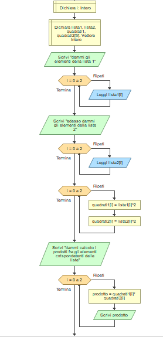

##### Dichiarazione la lista 1 e la lista 2

##### Richiesta all'utente di inserire numeri nella Lista 1

##### Richiesta all'utente di inserire numeri nella Lista 2

##### Calcolo dei quadrati per ogni numero nelle liste

##### Calcolo e visualizzazione dei prodotti tra i quadrati corrispondenti

```python
lista1 = [0] * (3)
lista2 = [0] * (3)
quadrati1 = [0] * (3)
quadrati2 = [0] * (3)

print("dammi gli elementi della lista 1")
for i in range(0, 2 + 1, 1):
    lista1[i] = int(input())
print("adesso dammi gli elementi della lista 2")
for i in range(0, 2 + 1, 1):
    lista2[i] = int(input())
for i in range(0, 2 + 1, 1):
    quadrati1[i] = lista1[i] ** 2
    quadrati2[i] = lista2[i] ** 2
print("dammi calcolo i prodotti fra gli elementi crrispondetenti delle liste")
for i in range(0, 2 + 1, 1):
    prodotto = quadrati1[i] * quadrati2[i]
    print(prodotto)
```

```
dammi gli elementi della lista 1
4
45
4
adesso dammi gli elementi della lista 2
3
3
34
dammi calcolo i prodotti fra gli elementi crrispondetenti delle liste
144
18225
18496
```

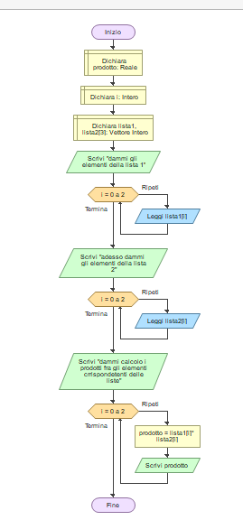

```python
lista1 = [0] * (3)
lista2 = [0] * (3)

print("dammi gli elementi della lista 1")
for i in range(0, 2 + 1, 1):
    lista1[i] = int(input())
print("adesso dammi gli elementi della lista 2")
for i in range(0, 2 + 1, 1):
    lista2[i] = int(input())
print("dammi calcolo i prodotti fra gli elementi crrispondetenti delle liste")
for i in range(0, 2 + 1, 1):
    prodotto = lista1[i] * lista2[i]
    print(prodotto)
```

```
dammi gli elementi della lista 1
```

```
adesso dammi gli elementi della lista 2
```

```
dammi calcolo i prodotti fra gli elementi crrispondetenti delle liste
6
2
6
```

# Confronto di Somme tra Due Coppie di Numeri

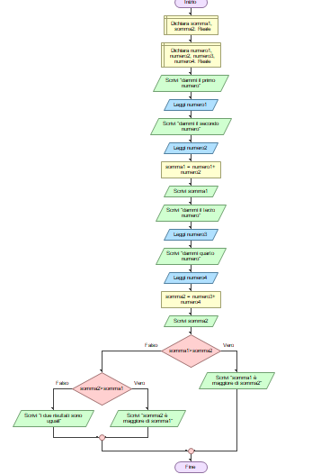

#### Chiediamo all'utente di scrivere due numeri, che chiamiamo numero1 e numero2.

#### Aggiungiamo numero1 e numero2 e chiamiamo il risultato somma1. Poi mostriamo somma1

#### Chiediamo all'utente di scrivere altri due numeri, che chiamiamo numero3 e numero4

#### Aggiungiamo numero3 e numero4 e chiamiamo il risultato somma2. Poi mostriamo somma2

#### Confrontiamo le somme: Guardiamo quale delle somme è più grande e mostriamo un messaggio corrispondente:

#### Se somma1 è più grande di somma2, diciamo "somma1 è più grande di somma2".

#### Se somma2 è più grande di somma1, diciamo "somma2 è più grande di somma1".

#### Se sono entrambe uguali, diciamo "i due risultati sono uguali".

```python
print("dammi il primo numero")
numero1 = float(input())
print("dammi il secondo numero")
numero2 = float(input())
somma1 = numero1 + numero2
print(somma1)
print("dammi il terzo numero")
numero3 = float(input())
print("dammi quarto numero")
numero4 = float(input())
somma2 = numero3 + numero4
print(somma2)
if somma1 > somma2:

    print("somma1 è maggiore di somma2")
else:
    if somma2 > somma1:
        print("somma2 è maggiore di somma1")
    else:
        print("i due risultati sono uguali")
```

```
dammi il primo numero
```

```
dammi il secondo numero
```

```
3.0
dammi il terzo numero
```

```
dammi quarto numero
```

```
7.0
somma2 è maggiore di somma1
```

# Ordinamento e Confronto di Tre Numeri

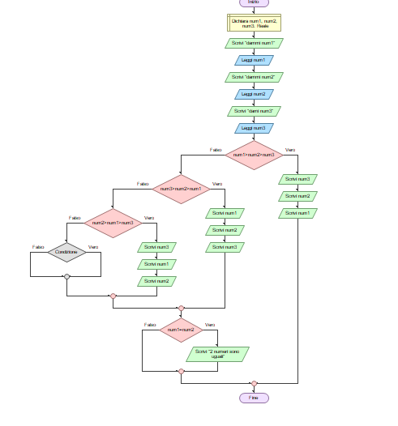

#### Dichiarazione di numero1 e numero 2 e numero 3

#### Scrivere dammi num1 num2 num3

#### Se num1 > num2> num 3 è giusto scrive da numero più piccolo al numero più grande

#### Se è falso apriamo un altro condizione num3>num2 > num1 se è vero scrive da numero piu piccolo al numero piu grande

#### Altrimenti continua a fare….

```python
print("dammi num1")
num1 = float(input())
print("dammi num2")
num2 = float(input())
print("dami num3")
num3 = float(input())
if (num1 > num2) > num3:
    print(num3)
    print(num2)
    print(num1)
else:
    if (num3 > num2) > num1:
        print(num1)
        print(num2)
        print(num3)
    else:
        if (num2 > num1) > num3:
            print(num3)
            print(num1)
            print(num2)
        else:
            # if Condizionale:
                # pass
    if num1 == num2:
        print("2 numeri sono uguali")
```

```
  Cell In[2], line 24
    if num1 == num2:
    ^
IndentationError: expected an indented block after 'else' statement on line 21
```

# Confronto di Due Numeri

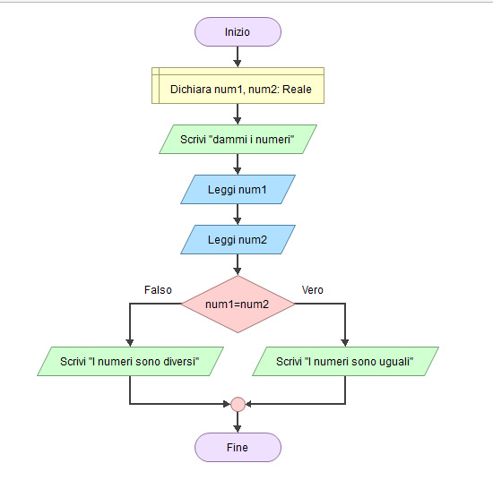

#### Dichiariamo num1 e num2 come numeri reali

#### Richiesta del num1 e num2

#### Verifica y due numeri e li compara

#### Se num1=num2 e vero stamperà "I numeri sono uguali"

#### Se num1=num2 e falso stamperò "I numeri sono diversi"

```python
print("dammi i numeri")
num1 = float(input())
num2 = float(input())
if num1 == num2:
    print("I numeri sono uguali")
else:
    print("I numeri sono diversi")
```

```
dammi i numeri
```

```
I numeri sono diversi
```

# Calcolo dei Quadrati da 1 a n

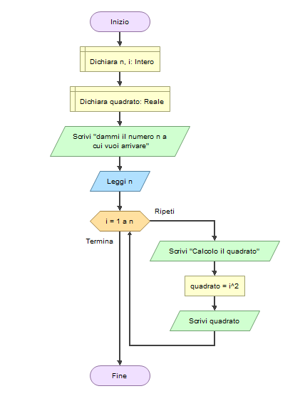

#### L'utente fornisce un numero intero n fino al quale vuole calcolare i quadrati.

#### Si utilizza un ciclo for che itera da 1 a n

#### All'interno del ciclo, si calcola il quadrato di ogni numero

#### Viene stampato il risultato del calcolo del quadrato per ogni numero

```python
print("dammi il numero n a cui vuoi arrivare")
n = int(input())
for i in range(1, n + 1, 1):
    print("Calcolo il quadrato")
    quadrato = i ** 2
    print(quadrato)
```

```
dammi il numero n a cui vuoi arrivare
```

```
Calcolo il quadrato
1
Calcolo il quadrato
4
Calcolo il quadrato
9
Calcolo il quadrato
16
Calcolo il quadrato
25
Calcolo il quadrato
36
Calcolo il quadrato
49
```

# Confronto tra Due Numeri

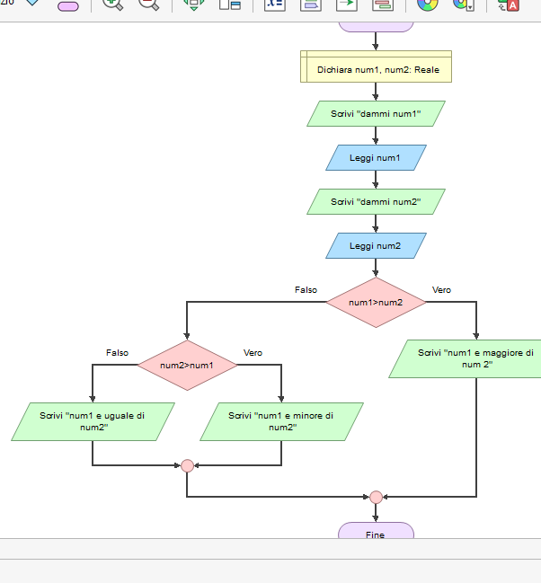

#### Dichiarazione di due numeri con le virgole

#### Inserire numero 1

#### Dire a programma di leggere questo numero

#### Inserire numero 2

#### Aggiungere una condizione dove dice se numero1 è maggiore di numero2

#### Se si il programma da il risultato come “numero1 è maggiore du numero2”

#### Se n o aggiungiamo un altra condizione dive dice che “numero 2 è maggiore di numero 1”

#### Se si il programma da il risultato num1 è minore di numero 2

#### Se no il programma da il risultati che dice “numero1 e uguale di numero 2

```python
print("dammi num1")
num1 = float(input())
print("dammi num2")
num2 = float(input())
if num1 > num2:
    print("num1 e maggiore di num 2")
else:
    if num2 > num1:
        print("num1 e minore di num2")
    else:
        print("num1 e uguale di num2")
```

# Verifica se un Numero è il Quadrato dell'Altro

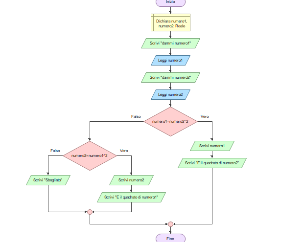

#### Dichiarazione numero 1 numero 2 con le virgole

#### Chiede al utente numero 1 e numero 2 e riconoscere

#### Creare una condizione se numero1 = numero2^2 stampa numero 1 e “il quadrato du numero 2 ” altrimenti ricreare un altro condizione se numero2= numero1^2 è vero stampa numero2 e “è il quadrato di numero1”

```python
## print("dammi numero1")
numero1 = float(input())
print("dammi numero2")
numero2 = float(input())
if numero1 == numero2 ** 2:
    print(numero1)
    print("E il quadrato di numero2")
else:
    if numero2 == numero1 ** 2:
        print(numero2)
        print("E il quadrato di numero1")
    else:
        print("Sbagliato")
```

```
dammi numero2
```

```
1.0
E il quadrato di numero2
```

# Calcolo della Somma o Differenza tra Due Numeri

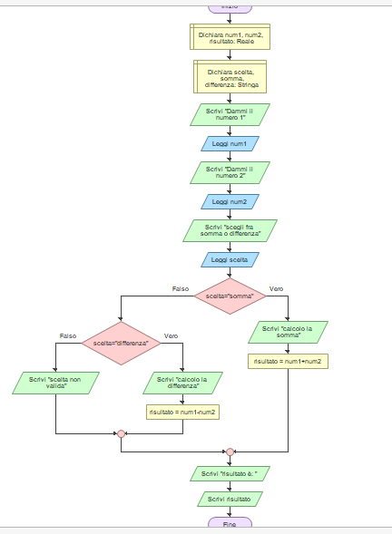

#### Chiede all'utente di inserire il primo numero.

#### L'utente inserisce il primo numero, convertito in un numero decimale e assegnato a num1.

#### Chiede all'utente di inserire il secondo numero.

#### L'utente inserisce il secondo numero, convertito in un numero decimale e assegnato a num2.

#### Chiede all'utente di scegliere tra "somma" e "differenza".

#### L'utente inserisce la scelta, assegnata a scelta.

#### Se la scelta è "somma", calcola la somma di num1 e num2, assegnando il risultato a risultato.

#### Se la scelta è "differenza", calcola la differenza di num1 e num2, assegnando il risultato a risultato.

#### Se la scelta non è né "somma" né "differenza", stampa "scelta non valida".

#### Stampa il risultato calcolato o il messaggio di scelta non valida, a seconda del caso.

```python
print("Dammi il numero 1")
num1 = float(input())
print("Dammi il numero 2")
num2 = float(input())
print("scegli fra somma o differenza")
scelta = input()
if scelta == "somma":
    print("calcolo la somma")
    risultato = num1 + num2
else:
    if scelta == "differenza":
        print("calcolo la differenza")
        risultato = num1 - num2
    else:
        print("scelta non valida")
print("risultato è: ")
print(risultato)
```

# Inserimento e Stampa di Cinque Numeri Interi

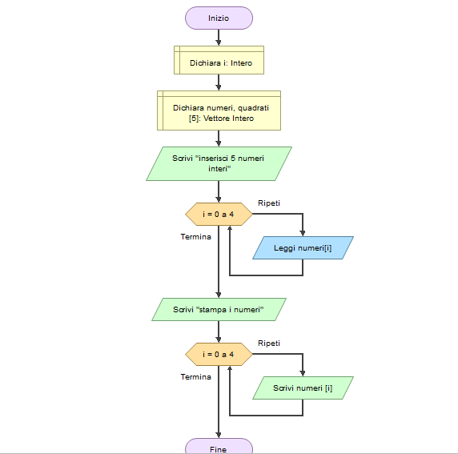

#### Crei due liste, 'numeri' e 'quadrati', entrambe con cinque elementi inizializzati a 0.

#### Chiedi all'utente di inserire cinque numeri interi e salva ciascun numero nella lista 'numeri' utilizzando un ciclo for.

```python
numeri = [0] * (5)
quadrati = [0] * (5)

print("inserisci 5 numeri interi")
for i in range(0, 4 + 1, 1):
    numeri[i] = int(input())
print("stampa i numeri")
for i in range(0, 4 + 1, 1):
    print(numeri[i])
```

```
inserisci 5 numeri interi
```

```
stampa i numeri
6
7
4
5
4
```

# Calcolo e Stampa dei Quadrati di Numeri Inseriti

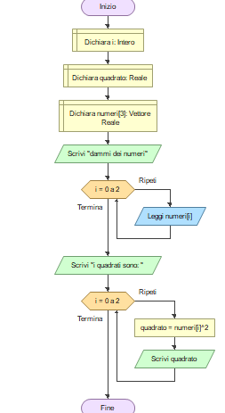

#### izializzazione: Crei una lista chiamata 'numeri' con tre elementi, tutti inizializzati a 0.

#### Input utente: Chiedi all'utente di inserire tre numeri e salva ciascun numero nella lista 'numeri' utilizzando un ciclo for.

#### Calcolo quadrati: Utilizzi un altro ciclo for per calcolare il quadrato di ciascun numero presente nella lista 'numeri'.

#### Stampa dei risultati: Stampa i risultati (quadrati dei numeri inseriti) uno per uno.

```python
numeri = [0] * (3)

print("dammi dei numeri")
for i in range(0, 2 + 1, 1):
    numeri[i] = float(input())
print("i quadrati sono: ")
for i in range(0, 2 + 1, 1):
    quadrato = numeri[i] ** 2
    print(quadrato)
```

```
dammi dei numeri
3
4
2
i quadrati sono:
9.0
16.0
4.0
```